**© [2026] [Placida Dassanayake]. All Rights Reserved.**

This notebook and its contents are protected by copyright. Unauthorized reproduction, distribution, or transmission of any part of this work, in any form or by any means, without the prior written permission of the copyright holder, is strictly prohibited.

# Module I: Probability

# Learning Objectives

Upon completion of this module, students will be able to:

- Formalize probability spaces using set-theoretic and axiomatic frameworks.
- Derive and apply fundamental probability laws from Kolmogorov axioms.
- Analyze dependence structures via conditional probability and independence.
- Construct and interpret Venn diagrams, tree diagrams, and contingency tables.
- Apply combinatorial methods to finite probability spaces.
- Compute probabilities using classical, conditional, and empirical frameworks.
- Translate verbal uncertainty problems into formal probabilistic models.

# Introduction

Probability theory provides the mathematical foundation for reasoning under uncertainty. It underlies modern statistical inference, stochastic modeling, and predictive analytics.

Applications include:

- Forecasting systems (weather, traffic, demand)
- Financial risk modeling
- Machine learning and Bayesian inference
- Reliability engineering
- Epidemiology and population dynamics

A central objective of probability theory is to assign a coherent measure to uncertainty that is internally consistent and mathematically well-defined.

# Probability Foundations

## Basic Concepts

A **random experiment** is a well-defined process whose outcome is uncertain.

Let:

- $\Omega$ = sample space
- $\omega \in \Omega$ = outcome
- $A \subseteq \Omega$ = event

### Sample Space

The sample space $\Omega$ is the set of all possible outcomes.

### Event

An event $A$ is any subset of $\Omega$, i.e. $A \in 2^\Omega$.

## Classical Probability

If all outcomes are equally likely:

$$ P(A) = \frac{|A|}{|\Omega|} $$

This is valid under a uniform probability measure on finite spaces.

## Example 1.1 (Die Roll)

Let:

$$ \Omega = \{1,2,3,4,5,6\} $$

Let $A = \{2,4,6\}$.

Then:

$$ P(A) = \frac{3}{6} = \frac{1}{2} $$

## Example 1.2 (Coin Tossing)

Three coin flips:

$$ |\Omega| = 2^3 = 8 $$

This follows from the multiplication principle.

## Theorem 1 (Multiplication Principle)

If a process consists of $m$ independent stages where stage $i$ has $r_i$ outcomes, then:

$$ |\Omega| = \prod_{i=1}^{m} r_i $$

### Proof

The sample space is the Cartesian product:

$$ \Omega = S_1 \times S_2 \times \cdots \times S_m $$

Thus:

$$ |\Omega| = \prod_{i=1}^{m} |S_i| $$

$\blacksquare$

## Axioms of Probability (Kolmogorov)

A probability measure $P$ satisfies:

1. **Non-negativity** $$ P(A) \ge 0 $$
2. **Normalization** $$ P(\Omega) = 1 $$
3. **Additivity** If $A_i \cap A_j = \emptyset$, then: $$ P\left(\bigcup_i A_i\right) = \sum_i P(A_i) $$

## Derived Result: Complement Rule

$$ P(A^c) = 1 - P(A) $$

### Proof

Since $A \cup A^c = \Omega$,

$$ P(A) + P(A^c) = 1 $$

$\blacksquare$

# Conditional Probability and Set Operations

## Intersection

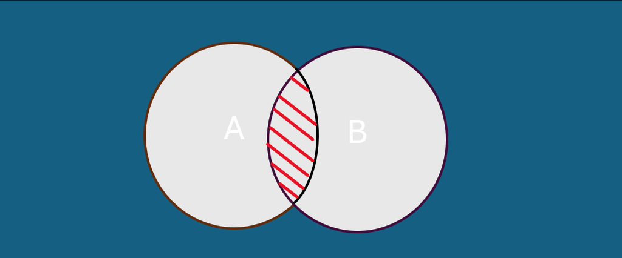

$$ A \cap B $$

represents simultaneous occurrence.

## Union

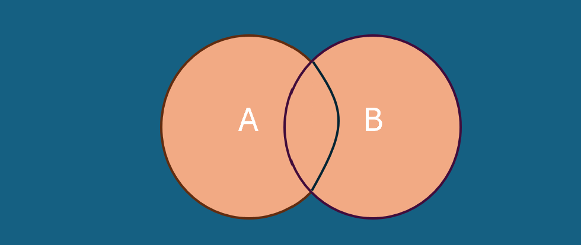

$$ A \cup B $$

represents occurrence of at least one event.

## Addition Rule

$$ P(A \cup B) = P(A) + P(B) - P(A \cap B) $$

#### Proof Sketch

Decompose:

$$ A \cup B = A \cup (B \setminus A) $$

where $B\setminus A= \{x∈B:x \notin A\}$

Apply disjoint additivity.

## Mutually Exclusive Events

$$ A \cap B = \emptyset \Rightarrow P(A \cap B) = 0 $$

## Conditional Probability

$$ P(A \mid B) = \frac{P(A \cap B)}{P(B)}, \quad P(B) > 0 $$

## Independence

$$ P(A \cap B) = P(A)P(B) $$

Equivalently:

$$ P(A \mid B) = P(A) $$

## Law of Total Probability

If $\{B_i\}$ partitions $\Omega$:

$$ P(A) = \sum_i P(A \mid B_i)P(B_i) $$

### Proof

$$ A = \bigcup_i (A \cap B_i) $$

Apply additivity:

$$ P(A) = \sum_i P(A \cap B_i) = \sum_i P(A \mid B_i)P(B_i) $$

$\blacksquare$

## De Morgan’s Laws

$$ (A \cup B)^c = A^c \cap B^c $$

$$ (A \cap B)^c = A^c \cup B^c $$

# Counting Theory

## Generalized Multiplication Rule

If $m_i$ steps have $r_i$ outcomes:

$$ \prod_{i=1}^k r_i^{m_i} $$

If you are selecting r number of objects from an n number of total objects, we could compute the total number of arrangements using either permutation or combination formulas. The key difference between permutations and combinations lies in the importance of order:

## Permutations

Permutations are used when the order of the element’s matters. This means that changing the order creates a different arrangement. When selecting r objects from a total of n object and the selection order matters and no repetitions allowed, total number of arrangements can be calculated using:

$$ P(n,r) = \frac{n!}{(n-r)!} $$

**Order matters**

## Combinations

Combinations, on the other hand, are used when the order of the elements does not matter. In this case, different arrangements of the same elements are considered the same. When selecting r objects from a total of n object and the selection order doesn’t matter and no repetitions allowed, total number of arrangements can be calculated using:

$$ C(n,r) = \frac{n!}{r!(n-r)!} $$

**Order does not matter**

## Theorem: Symmetry

$$ C(n,r) = C(n,n-r) $$

### Proof

Direct algebraic equivalence:

$$ \frac{n!}{r!(n-r)!} = \frac{n!}{(n-r)!r!} $$

$\blacksquare$

### Permutation example

You have 5 letters A, B C, D E. You are selecting 3 letters

(with out repetition) to create a password.

How many distinct possible passwords can you create?

In this case, the arrangements of the letters in the password

"ABC" (like "ABC," "ACB," "BAC," etc.) are considered distinct.

Hence when counting the total number of arrangements,

we use permutation formula where n = 5 and r = 3,

$$ 5P3 = \frac{5!}{(5-3)!} $$

### Combination example

You have 5 people named A, B C, D E. You are selecting 3 people

(with out repetition) to create committee.

How many distinct possible committees can you create?

In this case, the arrangements of the letters in the password "ABC"

(like "ABC," "ACB," "BAC," etc.) are considered same.

Hence, we do not need to count them as distinct possibilities.

Therefore, we must use combination formula to get the

total number of arrangements:

$$ 5C3 = \frac{5!}{3!(5-3)!} $$

## Example (Permutation)

Selecting ordered top 3 from 30 athletes:

$$ P(30,3) = \frac{30!}{27!} $$

## Example (Combination)

Selecting committee of size 3:

$$ C(30,3) = \frac{30!}{3!27!} $$

## Probability via Counting

Probabilit of an event A: $$ P(A) = \frac{n(A)}{n(S)} $$

where counts are often computed via permutations/combinations.

# Contingency Tables and Tree Diagrams

## Empirical Probability

$$ P(A) = \frac{\text{frequency of } A}{\text{total observations}} $$

## Conditional Structure in Tables

Joint probabilities:

$$ P(A \cap B) $$

Marginals:

$$ P(A) = \sum_B P(A \cap B) $$

## Tree Diagram Decomposition

For sequential events:

$$ P(A \cap B) = P(A)P(B \mid A) $$

Paths multiply along branches.

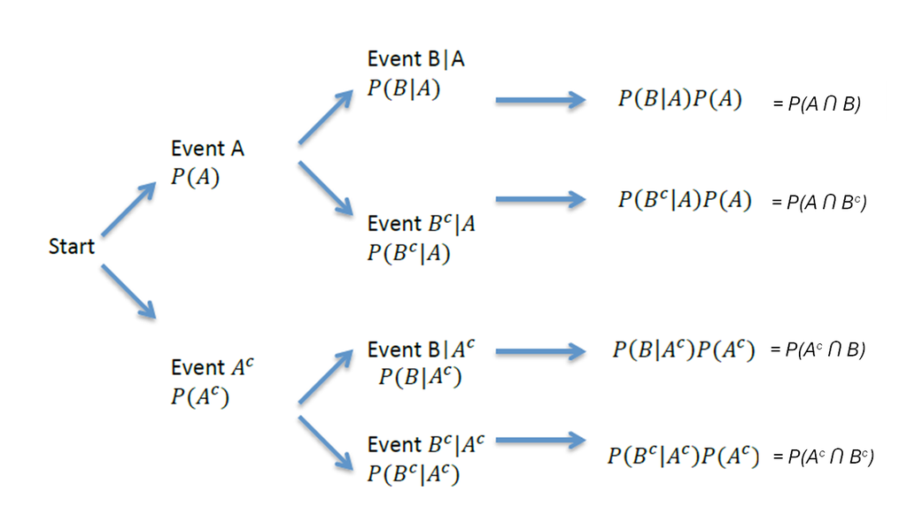

## Interpretation

- Horizontal structure: marginalization
- Vertical structure: conditioning
- Full tree: joint factorization

When collecting data in real life, we could tally our results into a two-way table and use the tally results to compute probabilities. This approach is often referred as empirical approach of computing probabilities, and the two-way table is called contingency table.

The following illustrates the general format of how information is presented in a **contingency table**:

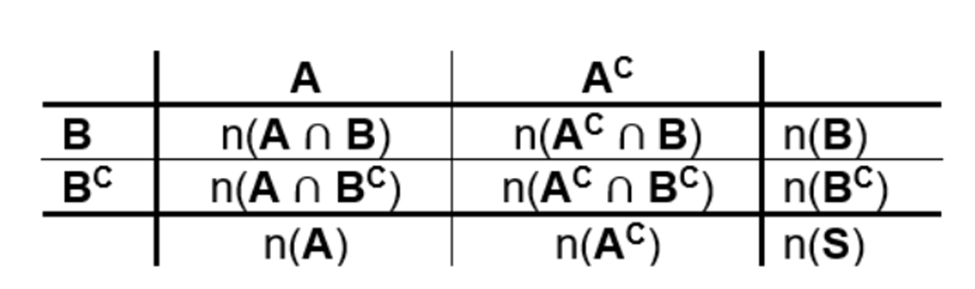

## Or

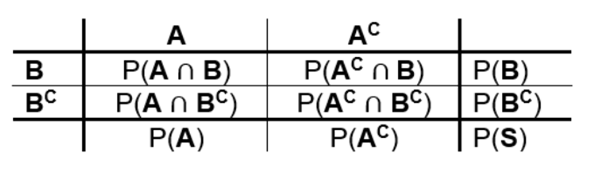

# Conceptual Summary

This module constructs a unified probability framework:

- Finite sample spaces → combinatorial measures
- Axioms → probability as measure theory
- Conditional probability → ratio structure
- Independence → factorization property
- Counting rules → discrete measure computation

These ideas form the foundation for:

- random variables
- expectation theory
- central limit theorem
- statistical inference

# Exercise Sheet — Probability and Combinatorial Reasoning

## Instructions

Answer all questions. Unless otherwise stated:

- Clearly justify your reasoning.
- Show intermediate steps.
- Identify and justify the probabilistic model used.
- Where appropriate, express answers in exact form rather than decimal approximations.

# Section A — Fundamental Structures of Uncertainty

### 1.

A process consists of selecting a card from a standard deck, rolling a die, and flipping a coin.

1. Define an appropriate sample space for this experiment using a structured representation.
2. Determine the total number of possible outcomes without explicitly listing them.
3. Justify your method using a formal counting principle.

### 2.

A system produces outcomes described by three sequential stages:

- Stage 1 has 4 outcomes
- Stage 2 has 6 outcomes
- Stage 3 has 2 outcomes
1. Construct the sample space cardinality.
2. Generalize this structure for $k$ stages.
3. Provide a proof of your generalization.

### 3.

Let $A$ and $B$ be events in a finite sample space.

Given:

- $P(A) = 0.55$
- $P(B) = 0.40$
- $P(A \cap B) = 0.25$

Compute:

1. $P(A \cup B)$
2. $P(A^c)$
3. $P(A^c \cap B)$
4. Determine whether $A$ and $B$ are mutually exclusive. Justify rigorously.

### 4.

Let $A$, $B$, and $C$ be events such that:

- $A$ occurs if a system passes test 1
- $B$ occurs if it passes test 2
- $C$ occurs if it passes test 3

Suppose:

- $P(A) = 0.6$
- $P(B \mid A) = 0.7$
- $P(C \mid A \cap B) = 0.8$

Compute:

1. $P(A \cap B \cap C)$
2. Interpret this result in terms of sequential system reliability.

# Section B — Logical Structure of Events

### 5.

Let $A$ and $B$ be events.

Prove or disprove:

1. $A \cap (B \cup A^c) = A \cap B$
2. $(A \cup B)^c = A^c \cap B^c$
3. $(A \cap B)^c = A^c \cup B^c$

Your answers must be justified using set-theoretic identities.

### 6.

A student claims:

> “If $P(A \cap B) = P(A)P(B)$, then $A$ and $B$ must be independent.”
1. Evaluate the correctness of this statement.
2. Provide a counterexample or proof.
3. Reformulate the correct definition of independence.

### 7.

Consider three events $A$, $B$, and $C$.

Show that:

$$ P(A \cup B \cup C) $$

can be decomposed into marginal, pairwise, and triple intersections. Derive the full expression.

# Section C — Conditional Reasoning and Sequential Models

### 8.

A medical test has the following properties:

- Prevalence of disease: 2%
- Sensitivity: 95%
- False positive rate: 8%
1. Construct a full probabilistic model.
2. Compute the probability that a randomly selected individual tests positive.
3. Given a positive test, compute the probability of actual disease.

### 9.

A system is tested twice. The probability of failure on each test depends on previous outcomes.

- $P(F_1) = 0.3$
- $P(F_2 \mid F_1) = 0.5$
- $P(F_2 \mid F_1^c) = 0.1$
1. Compute $P(F_1 \cap F_2)$
2. Compute $P(F_2)$
3. Interpret dependence structure.

### 10.

A decision process is modeled using a sequential tree:

- First branch: two outcomes
- Second branch: conditional outcomes depending on the first
1. Construct a general expression for joint probabilities along a path.
2. Explain how marginal probabilities are recovered from the tree.

# Section D — Counting and Discrete Structures

### 11.

A password is formed using 6 characters selected from 26 letters and 10 digits.

1. How many total passwords are possible if repetition is allowed?
2. How many are possible if repetition is not allowed?
3. How many contain exactly 2 digits?

### 12.

From a group of 12 students, a committee of 4 is formed.

1. How many committees are possible?
2. How many committees include a specific student?
3. Compare ordered vs unordered selection interpretations.

### 13.

A ranking system assigns gold, silver, and bronze medals to 20 participants.

1. How many possible outcomes exist?
2. Interpret this as a permutation structure.
3. Explain why combinations are not appropriate.

### 14.

A lottery selects 5 numbers from 49.

1. Compute the size of the sample space.
2. Compute the probability of selecting a specific ordered sequence.
3. Explain the difference between ordered and unordered modeling.

# Section E — Mixed Theoretical Problems

### 15.

Let $P$ be a probability measure on a finite sample space.

1. Prove that $P(\emptyset) = 0$ using axioms.
2. Prove that if $A \subseteq B$, then $P(A) \le P(B)$.
3. Show that: $$ P(A \cup B) \ge \max(P(A), P(B)) $$

### 16.

Consider a random experiment with unknown distribution.

1. Explain how probability can still be assigned without explicit enumeration.
2. Describe when classical probability fails.
3. Provide an alternative empirical interpretation.

### 17.

A system consists of multiple independent components.

Each component fails with probability $p$.

1. Derive the probability the system functions if all components must function.
2. Extend to the case where at least one failure is tolerated.
3. Generalize to $n$ components.

### 18.

Let $A$ and $B$ be events such that:

- $P(A) = 0.7$
- $P(B) = 0.6$
1. Determine bounds for $P(A \cap B)$.
2. Determine bounds for $P(A \cup B)$.
3. Explain why exact values cannot be determined.

# Section F — Conceptual Synthesis

### 19.

Explain how the following concepts are interconnected:

- sample space structure
- counting principles
- probability axioms
- conditional probability
- independence

Your answer should be formal and structured.

### 20.

A researcher states:

> “Probability is fundamentally a ratio of favorable to total outcomes.”

Critically evaluate this statement in modern probability theory. Include discussion of:

- measure-theoretic probability
- limitations of classical interpretation
- role of continuous sample spaces